# Pigmentation Score

Shayle Matsuda

05/20/2020

Matsuda, SB, Huffmyer, AS, Lenz, E, Davidson, J, Hancock, J, Pryzybylowski, A, Innis, T, Gates, RD, and KL Barott. Coral bleaching susceptibility is predictive of subsequent mortality within but not between coral species.

Pigmentation score data analysis for *M. capitata* and *P. compressa* tagged colonies at the Inner Lagoon and Outer Lagoon after the 2015 coral bleaching event in Kaneohe Bay. Tagged individuals were given a pigment score based on their visual color: 1) white (>80% of colony white with no visible pigmentation); 2) pale (>10% colony affected by pigment loss); or 3) fully pigmented (<10% colony with any pale coloration).

```r
#Bleaching df
bData<-read.csv("data/Bleaching_FINAL.csv") #read in bleaching df
bData$Site<-as.factor(bData$Site) #site as factor
bData$Pair<-as.factor(bData$Pair) #pair ID as factor

bALL<-bData
  #melt
  bALLData1<-melt(data = bALL, measure.vars = c("Month0","Month1.5","Month3","Month4.5", "Month6","Month10","Month18","Month24"))
  colnames(bALLData1)[colnames(bALLData1)=="variable"] <- "month"   # change col name from 'variable' to 'month'
  colnames(bALLData1)[colnames(bALLData1)=="value"] <- "score"   # change col name from 'value' to 'score'
  bALLData1$group<-paste(bALLData1$Species, bALLData1$Site, bALLData1$B2015, bALLData1$month) # add column for groups for figures only

#Remove all NON PAIRED corals and all NAs
  bALLData<-na.omit(bALLData1) # remove the NA rows (this removes individuals and NAs from pairs with no score at particular timepoints (due to not finding the coral))

  #Change month into TIME numeric for plots
  bALLData$time[bALLData$month=="Month0"]<-0
  bALLData$time[bALLData$month=="Month1.5"]<-1.5
  bALLData$time[bALLData$month=="Month3"]<-3
  bALLData$time[bALLData$month=="Month4.5"]<-4.5
  bALLData$time[bALLData$month=="Month6"]<-6
  bALLData$time[bALLData$month=="Month10"]<-10
  bALLData$time[bALLData$month=="Month18"]<-18
  bALLData$time[bALLData$month=="Month19"]<-19
  bALLData$time[bALLData$month=="Month24"]<-24

#Subsets of df for Mcap and Pcomp
Mcap_df<-subset(bALLData, Species=="Montipora capitata")   #Mcap only
Pcomp_df<-subset(bALLData, Species=="Porites compressa")   #Pcomp only

#Mean bleaching scores full df
#calc average bleaching  score per grouping by time point
ballmeans <- ddply(bALLData, c("Site", "Species", "B2015", "time"), summarise, #
                   N    = length(score[!is.na(score)]), #calculate the length of the data frame, excluding NA’s *this part is important*
                   mean = mean(score, na.rm=TRUE), #calculate mean of response variable, removing NA's
                   sd   = sd(score, na.rm=TRUE), #calculate standard deviation
                   se   = sd / sqrt(N), #calculate standard error
                   max = max(score, na.rm=TRUE) #calculate max
)

ballmeans$code<-paste0(ballmeans$Site, ballmeans$B2015, ballmeans$Species)
ballmeans #display table
```

# Figure 5

Average color score (A-D) and partial mortality (E-H) of bleaching susceptible versus bleaching resistant colonies of Montipora capitata (A, B, E, F) and Porites compressa (C, D, G, H) at the Inner Lagoon (A,C, E, G) and Outer Lagoon (B, D, F, H) from the peak of the coral bleaching event (Sept. – Oct. 2015) through the following 24 months of recovery. Solid lines indicate bleaching resistant colonies; dashed lines indicate bleaching susceptible colonies. Color scores: 1, white; 2, pale; 3, pigmented. Error bars indicate SEM.

```r
#subset for Mcap only
Mcap024Allplot<-subset(ballmeans, Species=="Montipora capitata")     #subset Mcap
#subset by reef
#PR13
Mcap024AllplotPR13<-subset(Mcap024Allplot, Site==13)
#PR4
Mcap024AllplotPR4<-subset(Mcap024Allplot, Site==4)
```

```r
#*M. capitata* Outer Lagoon Plot

ballplotMcapPR13<-ggplot(data=Mcap024AllplotPR13, aes(x=time, y=mean, group = code, color=B2015)) + #color by bleaching hist.
  geom_errorbar(aes(ymin=mean-se, ymax=mean+se),
                width=0.1,show.legend = FALSE)+
  geom_point(aes(shape=B2015),fill="black", size=5)+
  scale_shape_manual(values=c(16,1))+
  geom_line(aes(color=B2015,linetype=B2015))+
  scale_linetype_manual(values=c("solid", "dotted"))+
  scale_color_manual(values=c("black","black"))+
    scale_x_continuous(breaks = seq(0, 24, by = 6))+
  ylab("Color score") +
    xlab("Recovery Time (times)") + #Label the X Axis
    ylim(1, 3) + #set Y limits
  theme_bw() + #Set the background color
  theme(axis.line = element_line(color = 'black'), #Set the axes color
        axis.title=element_text(size=14,face="bold"), #Set axis format
        panel.border = element_blank(), #Set the border
        panel.grid.major = element_blank(), #Set the major gridlines
        panel.grid.minor = element_blank(), #Set the minor gridlines
        plot.background =element_blank(), #Set the plot background
        legend.key = element_blank()) + #Set plot legend key
  ggtitle("Outer Lagoon")+
          theme(plot.title = element_text(size=20,face = "bold",hjust = 0.5))
McapOuter<-ballplotMcapPR13 + theme(legend.position = "none") #remove legend
```

```r
#*M. capitata* Inner Lagoon Plot

ballplotMcapPR4<-ggplot(data=Mcap024AllplotPR4, aes(x=time, y=mean, group = code, color=B2015),show.legend = FALSE) + #color by bleaching hist.
 geom_errorbar(aes(ymin=mean-se, ymax=mean+se),
                width=0.1,show.legend = FALSE)+
  geom_point(aes(shape=B2015),fill="mediumblue", size=5)+

  scale_shape_manual(values=c( 16,1))+

  geom_line(aes(color=B2015, linetype=B2015))+
  scale_linetype_manual(values=c("solid", "dotted"))+
  scale_color_manual(values=c("black","black"))+
    scale_x_continuous(breaks = seq(0, 24, by = 6))+
  ylab("Montipora capitata\nColor score") +
    xlab("Recovery Time (times)") + #Label the X Axis
    ylim(1, 3) + #set Y limits
  theme_bw() + #Set the background color
  theme(axis.line = element_line(color = 'black'), #Set the axes color
        axis.title=element_text(size=14,face="bold"), #Set axis format
        panel.border = element_blank(), #Set the border
        panel.grid.major = element_blank(), #Set the major gridlines
        panel.grid.minor = element_blank(), #Set the minor gridlines
        plot.background =element_blank(), #Set the plot background
        legend.key = element_blank()) + #Set plot legend key
  ggtitle("Inner Lagoon")+
          theme(plot.title = element_text(size=20,face = "bold", hjust = 0.5))
McapInner<-ballplotMcapPR4 + theme(legend.position = "none") #remove legend
```

```r
#*Porites compressa*  df setup

Pcomp024Allplot<-subset(ballmeans, Species=="Porites compressa")
#subset by reef
Pcomp024AllplotPR13<-subset(Pcomp024Allplot, Site==13)
Pcomp024AllplotPR4<-subset(Pcomp024Allplot, Site==4)
```

```r
#*P. compress* Outer Lagoon Plot
b024plotPcompPR13<-ggplot(data=Pcomp024AllplotPR13, aes(x=time, y=mean, group = code, color=B2015)) + #color by bleaching hist.
  geom_errorbar(aes(ymin=mean-se, ymax=mean+se),
                width=0.1,show.legend = FALSE)+
  geom_point(aes(shape=B2015),fill="mediumblue", size=5)+
  scale_shape_manual(values=c( 16,1))+
  geom_line(aes(color=B2015, linetype=B2015))+
  scale_linetype_manual(values=c("solid", "dotted"))+
  scale_color_manual(values=c("black","black"))+
    scale_x_continuous(breaks = seq(0, 24, by = 6))+
  ylab("Color score") +
    xlab("Recovery Time (times)") + #Label the X Axis
    ylim(1, 3) + #set Y limits
  theme_bw() + #Set the background color
  theme(axis.line = element_line(color = 'black'), #Set the axes color
        axis.title=element_text(size=14,face="bold"), #Set axis format
        panel.border = element_blank(), #Set the border
        panel.grid.major = element_blank(), #Set the major gridlines
        panel.grid.minor = element_blank(), #Set the minor gridlines
        plot.background =element_blank(), #Set the plot background
        legend.key = element_blank()) + #Set plot legend key
  ggtitle("Porites compressa Bleaching Scores times 0-24")+
          theme(plot.title = element_text(size=20,face = "italic"))

PcompOuter<-b024plotPcompPR13+ theme(legend.position = "none") #remove legend
```

```r
#*P. compressa* Inner Lagoon
b024plotPcompPR4<-ggplot(data=Pcomp024AllplotPR4, aes(x=time, y=mean, group = code, color=B2015)) + #color by bleaching hist.
  geom_errorbar(aes(ymin=mean-se, ymax=mean+se),
                width=0.1,show.legend = FALSE)+
  geom_point(aes(shape=B2015),fill="mediumblue", size=5)+
  scale_shape_manual(values=c( 16,1))+
  geom_line(aes(color=B2015, linetype=B2015))+
  scale_linetype_manual(values=c("solid", "dotted"))+
  scale_color_manual(values=c("black","black"))+
    scale_x_continuous(breaks = seq(0, 24, by = 6))+
  ylab("Porites compressa\nColor score") +
    xlab("Recovery Time (times)") + #Label the X Axis
    ylim(1, 3) + #set Y limits
  theme_bw() + #Set the background color
  theme(axis.line = element_line(color = 'black'), #Set the axes color
        axis.title=element_text(size=14,face="bold"), #Set axis format
        panel.border = element_blank(), #Set the border
        panel.grid.major = element_blank(), #Set the major gridlines
        panel.grid.minor = element_blank(), #Set the minor gridlines
        plot.background =element_blank(), #Set the plot background
        legend.key = element_blank()) + #Set plot legend key
  #Sggtitle("Porites compressa Bleaching Scores times 0-24")+
          theme(plot.title = element_text(size=20,face = "italic"))
PcompInner<-b024plotPcompPR4+ theme(legend.position = "none") #remove legend
```

Figure 5 (A, B, C, D) *(color score figure, full figure includes Mortality data (see Partial_Mortality.Rmd))*

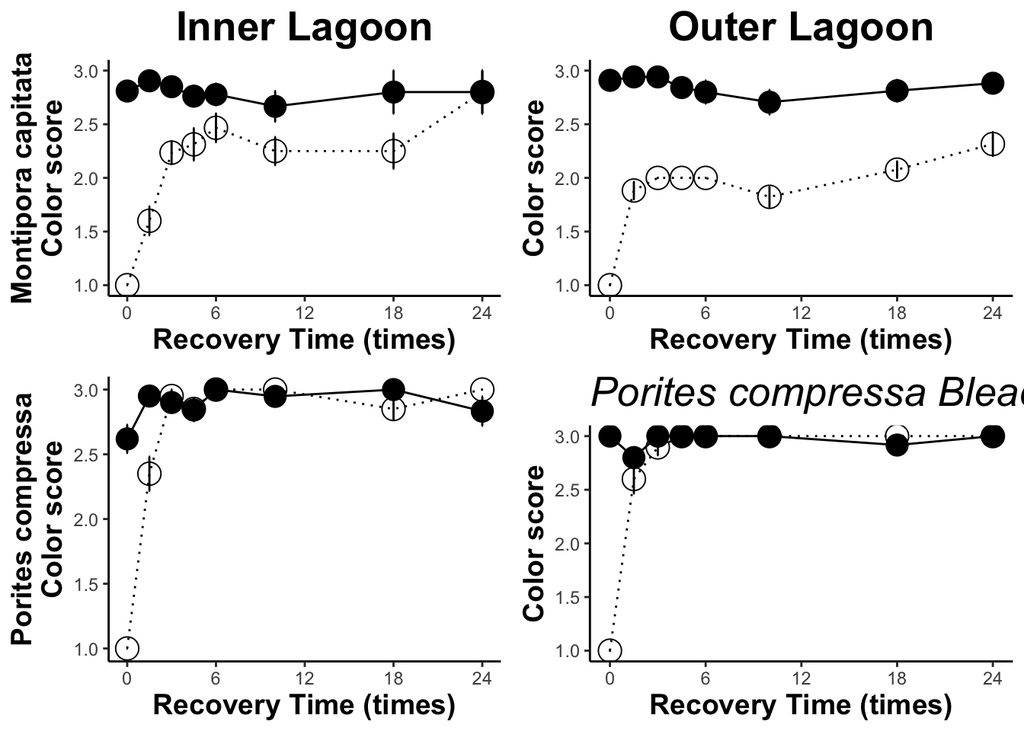

```r
grid.arrange(McapInner, McapOuter, PcompInner,PcompOuter, nrow = 2)
```

# Table 2: Color score recovery

Type II Analysis of Variance Table with Satterthwaite approximation for the effects of bleaching phenotype, lagoon, and recovery time across the course of the study, on pigmentation recovery of bleaching susceptible and resistant colonies for Montipora capitata and Porites compressa at Inner and Outer lagoons (`Color Score~Phenotype*Lagoon*Month+(1|Coral Tag ID)`). Bold indicates statistical significance (p<0.05).  
*M. capitata* `lmer(score~month*B2015*lagoon+(1|TagID)`

```r
#full model (all months)
Mcap_df_mod<-lmer(score~B2015*Site*month+(1|TagID), data=Mcap_df)
#summary(Mcap_df_mod)
anova(Mcap_df_mod, type=2) #pvals
```

```
## Type II Analysis of Variance Table with Satterthwaite's method
##                  Sum Sq Mean Sq NumDF  DenDF  F value  Pr(>F)
## B2015            32.430  32.430     1  81.43 320.4835 < 2e-16 ***
## Site              0.148   0.148     1  84.01   1.4591 0.23046
## month            23.536   3.362     7 416.77  33.2269 < 2e-16 ***
## B2015:Site        0.480   0.480     1  84.16   4.7416 0.03224 *
## B2015:month      28.071   4.010     7 416.97  39.6298 < 2e-16 ***
## Site:month        1.835   0.262     7 418.65   2.5901 0.01264 *
## B2015:Site:month  1.857   0.265     7 418.69   2.6215 0.01167 *
## ---
## Signif. codes:  0 '***' 0.001 '**' 0.01 '*' 0.05 '.' 0.1 ' ' 1
```

posthoc:

```r
 #posthoc
  emm<-emmeans(Mcap_df_mod,  ~ month)
  pairs(emm)

 emm<-emmeans(Mcap_df_mod,  ~ B2015*month)
  pairs(emm)
  cld(emm)
```

*P. compressa* `lmer(score~month*B2015*lagoon+(1|TagID)`

```r
#pcomp full model
Pcomp_df_mod2<-lmer(score~B2015*Site*month+(1|TagID), data=Pcomp_df)
#summary(Pcomp_df_mod2)
anova(Pcomp_df_mod2, type=2) #pvals
```

```
## Type II Analysis of Variance Table with Satterthwaite's method
##                  Sum Sq Mean Sq NumDF  DenDF  F value    Pr(>F)
## B2015            11.290 11.2905     1  76.98 167.5789 < 2.2e-16 ***
## Site              0.556  0.5560     1  77.86   8.2527 0.0052415 **
## month            77.678 11.0969     7 483.42 164.7052 < 2.2e-16 ***
## B2015:Site        0.009  0.0085     1  77.87   0.1263 0.7232419
## B2015:month      56.076  8.0109     7 483.44 118.9016 < 2.2e-16 ***
## Site:month        0.635  0.0907     7 484.54   1.3456 0.2267128
## B2015:Site:month  1.957  0.2796     7 484.13   4.1503 0.0001893 ***
## ---
## Signif. codes:  0 '***' 0.001 '**' 0.01 '*' 0.05 '.' 0.1 ' ' 1
```

posthoc:

```r
  emm<-emmeans(Pcomp_df_mod2,  ~ B2015*Site*month)
  pairs(emm)
  emm<-emmeans(Pcomp_df_mod2,  ~ Site*month)
  pairs(emm)
  emm<-emmeans(Pcomp_df_mod2,  ~ B2015*month)
  pairs(emm)
  emm<-emmeans(Pcomp_df_mod2,  ~ B2015*month*Site)
  pairs(emm)
```

# Supplementary Table 5

Analysis of Variance Table of the effects of lagoon and bleaching phenotype on pigmentation score of Montipora capitata and Porites compressa by recovery month from peak bleaching to 24 months of recovery (`Color Score ~ Lagoon*Phenotype+(1|Coral Tag ID)`). Bold indicates statistical significance. *M. capitata*

```r
Mcap_0<-subset(Mcap_df, month=="Month0")
Mcap_1.5<-subset(Mcap_df, month=="Month1.5")
Mcap_3<-subset(Mcap_df, month=="Month3")
Mcap_4.5<-subset(Mcap_df, month=="Month4.5")
Mcap_6<-subset(Mcap_df, month=="Month6")
Mcap_10<-subset(Mcap_df, month=="Month10")
Mcap_18<-subset(Mcap_df, month=="Month18")
Mcap_24<-subset(Mcap_df, month=="Month24")
```

Month0

```r
Month0_mcap0<-lm(score~Site*B2015, Mcap_0)
#summary(Month0_mcap0)
anova(Month0_mcap0)
```

```
## Analysis of Variance Table
##
## Response: score
##            Df Sum Sq Mean Sq   F value Pr(>F)
## Site        1  0.053   0.053    0.8637 0.3554
## B2015       1 74.419  74.419 1206.8812 <2e-16 ***
## Site:B2015  1  0.053   0.053    0.8637 0.3554
## Residuals  82  5.056   0.062
## ---
## Signif. codes:  0 '***' 0.001 '**' 0.01 '*' 0.05 '.' 0.1 ' ' 1
```

Month1.5

```r
Month1.5_mcap1.5<-lm(score~Site*B2015, Mcap_1.5)
#summary(Month1.5_mcap1.5)
anova(Month1.5_mcap1.5)
```

```
## Analysis of Variance Table
##
## Response: score
##            Df  Sum Sq Mean Sq  F value Pr(>F)
## Site        1  0.3826  0.3826   2.4006 0.1257
## B2015       1 26.6877 26.6877 167.4554 <2e-16 ***
## Site:B2015  1  0.2810  0.2810   1.7631 0.1885
## Residuals  71 11.3154  0.1594
## ---
## Signif. codes:  0 '***' 0.001 '**' 0.01 '*' 0.05 '.' 0.1 ' ' 1
```

Month3

```r
Month3_mcap3<-lm(score~Site*B2015, Mcap_3)
#summary(Month3_mcap3)
anova(Month3_mcap3)
```

```
## Analysis of Variance Table
##
## Response: score
##            Df  Sum Sq Mean Sq  F value    Pr(>F)
## Site        1  0.2193  0.2193   2.2769   0.13595
## B2015       1 10.7393 10.7393 111.4917 5.644e-16 ***
## Site:B2015  1  0.4775  0.4775   4.9574   0.02929 *
## Residuals  68  6.5500  0.0963
## ---
## Signif. codes:  0 '***' 0.001 '**' 0.01 '*' 0.05 '.' 0.1 ' ' 1
```

posthoc:

```r
emm<-emmeans(Month3_mcap3,  ~ B2015*Site)
  pairs(emm)
  cld(emm)
```

Month4.5

```r
Month4.5_mcap4.5<-lm(score~Site*B2015, Mcap_4.5)
#summary(Month4.5_mcap4.5)
anova(Month4.5_mcap4.5)
```

```
## Analysis of Variance Table
##
## Response: score
##            Df  Sum Sq Mean Sq F value    Pr(>F)
## Site        1  0.4699  0.4699  2.8735   0.09437 .
## B2015       1  8.0188  8.0188 49.0390 1.092e-09 ***
## Site:B2015  1  0.7249  0.7249  4.4329   0.03874 *
## Residuals  72 11.7733  0.1635
## ---
## Signif. codes:  0 '***' 0.001 '**' 0.01 '*' 0.05 '.' 0.1 ' ' 1
```

posthoc:

```r
 emm<-emmeans(Month4.5_mcap4.5,  ~ B2015*Site)
  pairs(emm)
```

Month6

```r
Month6_mcap6<-lm(score~Site*B2015, Mcap_6)
#summary(Month6_mcap6)
anova(Month6_mcap6)
```

```
## Analysis of Variance Table
##
## Response: score
##            Df Sum Sq Mean Sq F value    Pr(>F)
## Site        1 0.7646  0.7646  4.7974   0.03254 *
## B2015       1 4.5082  4.5082 28.2849 1.754e-06 ***
## Site:B2015  1 0.9182  0.9182  5.7606   0.01962 *
## Residuals  58 9.2444  0.1594
## ---
## Signif. codes:  0 '***' 0.001 '**' 0.01 '*' 0.05 '.' 0.1 ' ' 1
```

posthoc:

```r
emm<-emmeans(Month6_mcap6,  ~ Site)
  pairs(emm)
  emm<-emmeans(Month6_mcap6,  ~ B2015*Site)
  pairs(emm)
```

Month10

```r
Month10_mcap10<-lm(score~Site*B2015, Mcap_10)
#summary(Month10_mcap10)
anova(Month10_mcap10)
```

```
## Analysis of Variance Table
##
## Response: score
##            Df  Sum Sq Mean Sq F value    Pr(>F)
## Site        1  0.5275  0.5275  2.6092   0.11208
## B2015       1  6.8966  6.8966 34.1142 3.066e-07 ***
## Site:B2015  1  0.7628  0.7628  3.7731   0.05731 .
## Residuals  54 10.9167  0.2022
## ---
## Signif. codes:  0 '***' 0.001 '**' 0.01 '*' 0.05 '.' 0.1 ' ' 1
```

Month18

```r
Month18_mcap18<-lm(score~Site*B2015, Mcap_18)
#summary(Month18_mcap18)
anova(Month18_mcap18)
```

```
## Analysis of Variance Table
##
## Response: score
##            Df Sum Sq Mean Sq F value    Pr(>F)
## Site        1 0.0040  0.0040  0.0271    0.8700
## B2015       1 4.7374  4.7374 31.8027 1.778e-06 ***
## Site:B2015  1 0.0742  0.0742  0.4978    0.4848
## Residuals  38 5.6606  0.1490
## ---
## Signif. codes:  0 '***' 0.001 '**' 0.01 '*' 0.05 '.' 0.1 ' ' 1
```

Month24

```r
Month24_mcap24t<-lm(score~Site*B2015, Mcap_24)
#summary(Month24_mcap24t)
anova(Month24_mcap24t)
```

```
## Analysis of Variance Table
##
## Response: score
##            Df Sum Sq Mean Sq F value    Pr(>F)
## Site        1 0.3674 0.36739  2.0657 0.1580582
## B2015       1 2.2524 2.25242 12.6643 0.0009408 ***
## Site:B2015  1 0.6276 0.62761  3.5287 0.0672665 .
## Residuals  42 7.4700 0.17786
## ---
## Signif. codes:  0 '***' 0.001 '**' 0.01 '*' 0.05 '.' 0.1 ' ' 1
```

*P. compressa*

```r
Pcomp_0<-subset(Pcomp_df, month=="Month0")
Pcomp_1.5<-subset(Pcomp_df, month=="Month1.5")
Pcomp_3<-subset(Pcomp_df, month=="Month3")
Pcomp_4.5<-subset(Pcomp_df, month=="Month4.5")
Pcomp_6<-subset(Pcomp_df, month=="Month6")
Pcomp_10<-subset(Pcomp_df, month=="Month10")
Pcomp_18<-subset(Pcomp_df, month=="Month18")
Pcomp_24<-subset(Pcomp_df, month=="Month24")
```

Month0

```r
Month0_Pcomp0<-lm(score~Site*B2015, Pcomp_0)
#summary(Month0_Pcomp0)
anova(Month0_Pcomp0)
```

```
## Analysis of Variance Table
##
## Response: score
##            Df Sum Sq Mean Sq  F value    Pr(>F)
## Site        1  0.743   0.743   11.707 0.0009939 ***
## B2015       1 66.780  66.780 1051.793 < 2.2e-16 ***
## Site:B2015  1  0.743   0.743   11.707 0.0009939 ***
## Residuals  78  4.952   0.063
## ---
## Signif. codes:  0 '***' 0.001 '**' 0.01 '*' 0.05 '.' 0.1 ' ' 1
```

Month1.5

```r
Month1.5_Pcomp1.5<-lm(score~Site*B2015, Pcomp_1.5)
#summary(Month1.5_Pcomp1.5)
anova(Month1.5_Pcomp1.5)
```

```
## Analysis of Variance Table
##
## Response: score
##            Df Sum Sq Mean Sq F value    Pr(>F)
## Site        1   0.05  0.0500  0.2171 0.6425584
## B2015       1   3.20  3.2000 13.8971 0.0003695 ***
## Site:B2015  1   0.80  0.8000  3.4743 0.0661917 .
## Residuals  76  17.50  0.2303
## ---
## Signif. codes:  0 '***' 0.001 '**' 0.01 '*' 0.05 '.' 0.1 ' ' 1
```

posthoc:

```r
 emm<-emmeans(Month1.5_Pcomp1.5,  ~ B2015)
```

```
## NOTE: Results may be misleading due to involvement in interactions
```

```r
  pairs(emm)
```

```
##  contrast estimate    SE df t.ratio p.value
##  N - Y         0.4 0.107 76 3.728   0.0004
##
## Results are averaged over the levels of: Site
```

Month3

```r
Month3_Pcomp3<-lm(score~Site*B2015, Pcomp_3)
#summary(Month3_Pcomp3)
anova(Month3_Pcomp3)
```

```
## Analysis of Variance Table
##
## Response: score
##            Df Sum Sq  Mean Sq F value Pr(>F)
## Site        1 0.0098 0.009750  0.1589 0.6913
## B2015       1 0.0128 0.012821  0.2090 0.6489
## Site:B2015  1 0.1174 0.117443  1.9145 0.1706
## Residuals  74 4.5395 0.061344
```

Month4.5

```r
Month4.5_Pcomp4.5<-lm(score~Site*B2015, Pcomp_4.5)
#summary(Month4.5_Pcomp4.5)
anova(Month4.5_Pcomp4.5)
```

```
## Analysis of Variance Table
##
## Response: score
##            Df Sum Sq Mean Sq F value  Pr(>F)
## Site        1 0.4431 0.44308  6.1971 0.01514 *
## B2015       1 0.0003 0.00032  0.0044 0.94721
## Site:B2015  1 0.0003 0.00029  0.0041 0.94926
## Residuals  71 5.0763 0.07150
## ---
## Signif. codes:  0 '***' 0.001 '**' 0.01 '*' 0.05 '.' 0.1 ' ' 1
```

Month6

```r
Month6_Pcomp6<-lm(score~Site*B2015,Pcomp_6)
#summary(Month6_Pcomp6)
anova(Month6_Pcomp6)
```

```
## Analysis of Variance Table
##
## Response: score
##            Df     Sum Sq    Mean Sq F value Pr(>F)
## Site        1 3.8650e-29 3.8654e-29       1 0.3205
## B2015       1 3.8650e-29 3.8654e-29       1 0.3205
## Site:B2015  1 3.8650e-29 3.8654e-29       1 0.3205
## Residuals  76 2.9377e-27 3.8654e-29
```

Month10

```r
Month10_Pcomp10<-lm(score~Site*B2015, Pcomp_10)
#summary(Month10_Pcomp10)
anova(Month10_Pcomp10)
```

```
## Analysis of Variance Table
##
## Response: score
##            Df  Sum Sq  Mean Sq F value Pr(>F)
## Site        1 0.01333 0.013329  1.0271 0.3142
## B2015       1 0.01299 0.012991  1.0011 0.3204
## Site:B2015  1 0.01332 0.013324  1.0267 0.3143
## Residuals  73 0.94737 0.012978
```

Month18

```r
Month18_Pcomp18<-lm(score~Site*B2015,Pcomp_18)
#summary(Month18_Pcomp18)
anova(Month18_Pcomp18)
```

```
## Analysis of Variance Table
##
## Response: score
##            Df Sum Sq  Mean Sq F value  Pr(>F)
## Site        1 0.0162 0.016183  0.2708 0.60481
## B2015       1 0.0624 0.062446  1.0448 0.31096
## Site:B2015  1 0.1966 0.196640  3.2899 0.07488 .
## Residuals  58 3.4667 0.059770
## ---
## Signif. codes:  0 '***' 0.001 '**' 0.01 '*' 0.05 '.' 0.1 ' ' 1
```

Month24

```r
Month24_Pcomp24<-lm(score~Site*B2015,Pcomp_24)
#summary(Month24_Pcomp24)
anova(Month24_Pcomp24)
```

```
## Analysis of Variance Table
##
## Response: score
##            Df  Sum Sq  Mean Sq F value Pr(>F)
## Site        1 0.07971 0.079710  2.0087 0.1638
## B2015       1 0.08696 0.086957  2.1913 0.1463
## Site:B2015  1 0.07971 0.079710  2.0087 0.1638
## Residuals  42 1.66667 0.039683
```

# Supplementary Table 6

“Pairs” subset  
Type II Analysis of Variance Table with Satterthwaite approximation (p-values only) of the effects of lagoon and bleaching phenotype on pigmentation score of Montipora capitata and Porites compressa from peak bleaching to 24 months of recovery. “Full” models include data from all colonies found at each time point (`Color Score~Lagoon*Phenotype+(1|Coral Tag ID)`). “Pairs” models contain only colonies where both partners of each pair were found at a time point (“pairs” models not run for months if less than half of the original tagged corals were found) (`Color Score ~ Lagoon*Phenotype+(1|Coral Tag ID)+(1|Pair ID)`). Bold indicates statistical significance, and “n” equals the number of individual colonies in the “Full”/“Pairs” models at each time point.

*“Pairs” subset of full dataset with only colonies when both partners of a pair are found at each time point*

```r
naData<-bALLData   #subset only pairs
pData<-bALLData   #dataset to work from (pull unwanted from)

# Identify which pairs have a partner not found by month:
# Subset Month0 (two colonies missing values, checked datasheet)
M0<-subset(naData, month=="Month0") # subset month 0

  # subset month 0
  M0a<-c("TagID","Pair","Species", "Site","B2015","month","score") # which columns to pull
  M0<-pData[M0a]
  M0<-subset(M0, month=="Month0")

# Subset Month1.5
  M1.5<-subset(naData, month=="Month1.5") # subset month 1.5
  # subset month 1.5
  M1.5a<-c("TagID","Pair","Species", "Site","B2015","month","score") # which columns to pull
  M1.5<-pData[M1.5a]
  M1.5<-subset(M1.5, month=="Month1.5")
  M1.5<-M1.5[!(M1.5$Pair=="113_114"),]

## Subset Month3
M3<-subset(naData, month=="Month3") # subset month 3
  M3a<-c("TagID","Pair","Species", "Site","B2015","month", "score")
  M3<-pData[M3a]
  M3<-subset(M3, month=="Month3")
  M3<-M3[!(M3$Pair=="7_8"),]
  M3<-M3[!(M3$Pair=="113_114"),]
  M3<-M3[!(M3$Pair=="255_256"),]
  M3<-M3[!(M3$Pair=="259_260"),]

## Subset Month 4.5
  M4.5<-subset(naData, month=="Month4.5") # subset month 3
  M4.5a<-c("TagID","Pair","Species", "Site","B2015","month", "score")
  M4.5<-pData[M4.5a]
  M4.5<-subset(M4.5, month=="Month4.5")
  M4.5<-na.omit(M4.5) # remove the NA colums
  M4.5<-M4.5[!(M4.5$Pair=="7_8"),]
  M4.5<-M4.5[!(M4.5$Pair=="113_114"),]
  M4.5<-M4.5[!(M4.5$Pair=="255_256"),]
  M4.5<-M4.5[!(M4.5$Pair=="259_260"),]
  M4.5<-M4.5[!(M4.5$Pair=="263_264"),]
  M4.5<-M4.5[!(M4.5$Pair=="267_268"),]
  M4.5<-M4.5[!(M4.5$Pair=="82_83"),]

# Subset month 6
  M6<-subset(naData, month=="Month6")
  M6a<-c("TagID","Pair","Species", "Site","B2015","month","score")
  M6<-pData[M6a]
  M6<-subset(M6, month=="Month6")
  M6<-M6[!(M6$Pair=="111_112"),] # remove the other partner
  M6<-M6[!(M6$Pair=="115_116"),]
  M6<-M6[!(M6$Pair=="119_120"),]
  M6<-M6[!(M6$Pair=="207_208"),]
  M6<-M6[!(M6$Pair=="255_256"),]
  M6<-M6[!(M6$Pair=="259_260"),]
  M6<-M6[!(M6$Pair=="263_264"),]
  M6<-M6[!(M6$Pair=="267_268"),]
  M6<-M6[!(M6$Pair=="263_264"),]

# Subset month 10
  M10<-subset(naData, month=="Month10")
  M10a<-c("TagID","Pair","Species", "Site","B2015","month","score")
  M10<-pData[M10a]
  M10<-subset(M10, month=="Month10")
  M10<-M10[!(M10$Pair=="253_254"),] # remove the other partner
  M10<-M10[!(M10$Pair=="259_260"),]
  M10<-M10[!(M10$Pair=="113_114"),]
  M10<-M10[!(M10$Pair=="161_262"),]
  M10<-M10[!(M10$Pair=="263_264"),]
  M10<-M10[!(M10$Pair=="267_268"),]
  M10<-M10[!(M10$Pair=="271_272"),]
  M10<-M10[!(M10$Pair=="273_274"),]
  M10<-M10[!(M10$Pair=="275_276"),]
  M10<-M10[!(M10$Pair=="277_278"),]
  M10<-M10[!(M10$Pair=="31_32"),]
  M10<-M10[!(M10$Pair=="261_262"),]

  # Subset month 18
  M18<-subset(naData, month=="Month18")
  M18a<-c("TagID","Pair","Species", "Site","B2015","month","score")
  M18<-pData[M18a]
  M18<-subset(M18, month=="Month18")
  M18<-M18[!(M18$Pair=="253_254"),] # remove the other partner
  M18<-M18[!(M18$Pair=="259_260"),]
  M18<-M18[!(M18$Pair=="161_262"),]
  M18<-M18[!(M18$Pair=="263_264"),]
  M18<-M18[!(M18$Pair=="267_268"),]
  M18<-M18[!(M18$Pair=="271_272"),]
  M18<-M18[!(M18$Pair=="273_274"),]
  M18<-M18[!(M18$Pair=="275_276"),]
  M18<-M18[!(M18$Pair=="277_278"),]
  M18<-M18[!(M18$Pair=="31_2"),]
  M18<-M18[!(M18$Pair=="115_116"),]
  M18<-M18[!(M18$Pair=="119_120"),]
  M18<-M18[!(M18$Pair=="261_262"),]
  M18<-M18[!(M18$Pair=="269_270"),]
  M18<-M18[!(M18$Pair=="101_102"),]
  M18<-M18[!(M18$Pair=="117_118"),]
  M18<-M18[!(M18$Pair=="265_266"),]
  M18<-M18[!(M18$Pair=="19_20"),]
  M18<-M18[!(M18$Pair=="205_206"),]
  M18<-M18[!(M18$Pair=="223_224"),]
  M18<-M18[!(M18$Pair=="39_40"),]

  # Subset month 24
  M24<-subset(naData, month=="Month24")
  M24a<-c("TagID","Pair","Species", "Site","B2015","month","score")
  M24<-pData[M24a]
  M24<-subset(M24, month=="Month24")
  M24<-M24[!(M24$Pair=="107_108"),] # remove the other partner
  M24<-M24[!(M24$Pair=="13_14"),]
  M24<-M24[!(M24$Pair=="223_224"),]
  M24<-M24[!(M24$Pair=="231_232"),]
  M24<-M24[!(M24$Pair=="261_262"),]
  M24<-M24[!(M24$Pair=="263_264"),]
  M24<-M24[!(M24$Pair=="265_266"),]
  M24<-M24[!(M24$Pair=="283_284"),]
  M24<-M24[!(M24$Pair=="289_290"),]
  M24<-M24[!(M24$Pair=="31_32"),]
  M24<-M24[!(M24$Pair=="33_34"),]
  M24<-M24[!(M24$Pair=="39_40"),]
  M24<-M24[!(M24$Pair=="76_77"),]
  M24<-M24[!(M24$Pair=="78_79"),]

#make dfs
PairDat<-rbind(M0,M1.5,M3,M4.5,M6,M10,M18,M24)

#Mean bleaching scores across the entire project
#calc average bleaching score per grouping by time point
pairmeans <- ddply(PairDat, c("Site", "Species", "B2015", "month"), summarise, #
                   N    = length(score[!is.na(score)]), #calculate the length of the data frame, excluding NA’s *this part is important*
                   mean = mean(score, na.rm=TRUE), #calculate mean of response variable, removing NA's
                   sd   = sd(score, na.rm=TRUE), #calculate standard deviation
                   se   = sd / sqrt(N), #calculate standard error
                   max = max(score, na.rm=TRUE) #calculate max
)

pairmeans$code<-paste0(pairmeans$Site, pairmeans$B2015, pairmeans$Species)
```

*Montipora capitata* “Pairs” plots

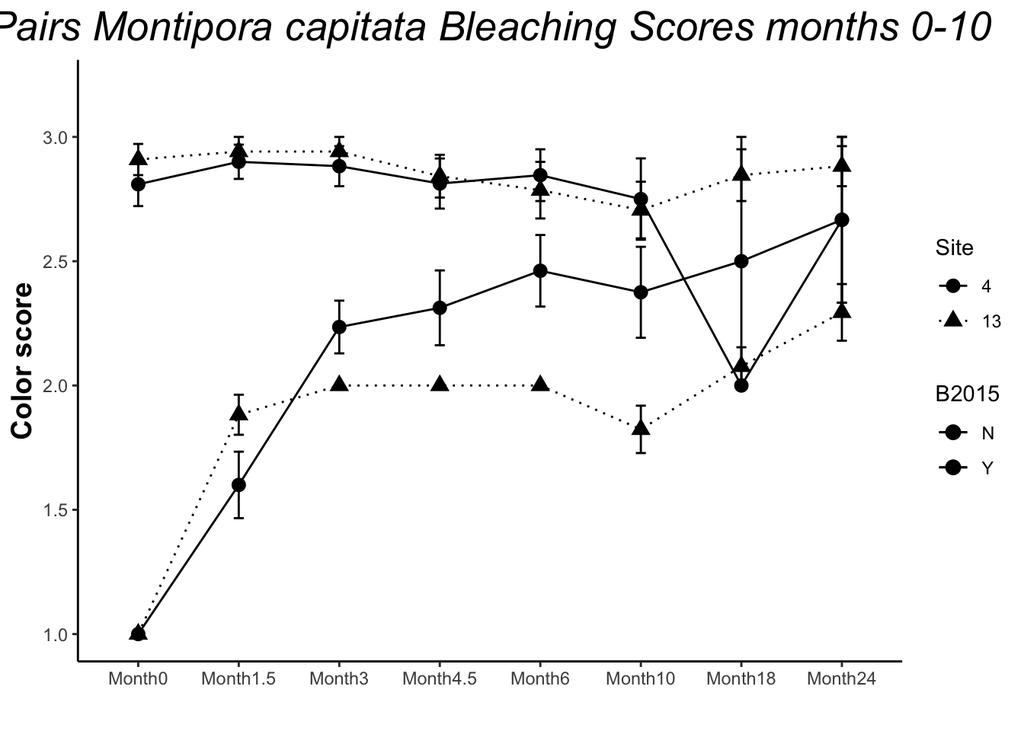

```r
#subset for Mcap only
McapPairplot<-subset(pairmeans, Species=="Montipora capitata")

PairplotMcapB<-ggplot(data=McapPairplot, aes(x=month, y=mean, group = code, color=B2015)) + #color by bleaching hist.
  geom_errorbar(aes(ymin=mean-se, ymax=mean+se),
                width=0.1)+
  geom_point(aes(shape=Site), size=3)+
  geom_line(aes(color=B2015, linetype=Site))+
  scale_linetype_manual(values=c("solid", "dotted"))+
  scale_color_manual(values=c("black","black"))+
  ylab("Color score") +
    xlab("") + #Label the X Axis
    ylim(1, 3.2) + #set Y limits
  theme_bw() + #Set the background color
  theme(axis.line = element_line(color = 'black'), #Set the axes color
        axis.title=element_text(size=14,face="bold"), #Set axis format
        panel.border = element_blank(), #Set the border
        panel.grid.major = element_blank(), #Set the major gridlines
        panel.grid.minor = element_blank(), #Set the minor gridlines
        plot.background =element_blank(), #Set the plot background
        legend.key = element_blank()) + #Set plot legend key
  ggtitle("Pairs Montipora capitata Bleaching Scores months 0-10")+
          theme(plot.title = element_text(size=20,face = "italic",hjust = 0.5));PairplotMcapB
```

*Porites compressa* “Pairs” plots

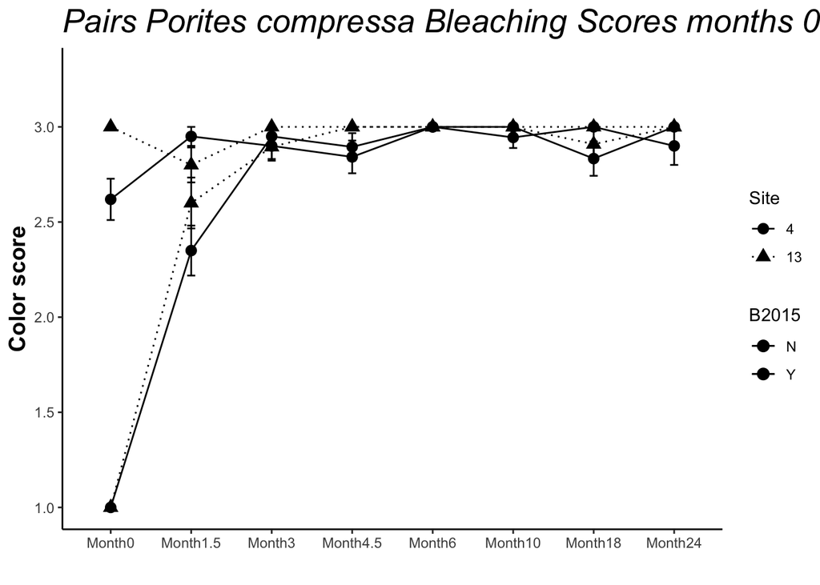

```r
#subset for Pcomp only
PcompPairplot<-subset(pairmeans, Species=="Porites compressa")

PairplotPcompB<-ggplot(data=PcompPairplot, aes(x=month, y=mean, group = code, color=B2015)) + #color by bleaching hist.
  geom_errorbar(aes(ymin=mean-se, ymax=mean+se),
                width=0.1)+
  geom_point(aes(shape=Site), size=3)+
  geom_line(aes(color=B2015, linetype=Site))+
  scale_linetype_manual(values=c("solid", "dotted"))+
  scale_color_manual(values=c("black","black"))+
  ylab("Color score") +
    xlab("") + #Label the X Axis
    ylim(1, 3.3) + #set Y limits
  theme_bw() + #Set the background color
  theme(axis.line = element_line(color = 'black'), #Set the axes color
        axis.title=element_text(size=14,face="bold"), #Set axis format
        panel.border = element_blank(), #Set the border
        panel.grid.major = element_blank(), #Set the major gridlines
        panel.grid.minor = element_blank(), #Set the minor gridlines
        plot.background =element_blank(), #Set the plot background
        legend.key = element_blank()) + #Set plot legend key
  ggtitle("Pairs Porites compressa Bleaching Scores months 0-10")+
          theme(plot.title = element_text(size=20,face = "italic"));PairplotPcompB
```

```r
#set up Pairs data
Mcappig<-subset(PairDat, Species =="Montipora capitata")
#All lmer
MpigPair_all_mod1<-lmer(score~Site*B2015*month+(1|TagID)+(1|Pair), Mcappig)
#summary(MpigPair_all_mod1)
anova(MpigPair_all_mod1, type=2)
```

```
## Type II Analysis of Variance Table with Satterthwaite's method
##                  Sum Sq Mean Sq NumDF  DenDF  F value    Pr(>F)
## Site              0.079   0.079     1  41.89   0.8377  0.365290
## B2015            35.817  35.817     1  36.15 382.0950 < 2.2e-16 ***
## month            21.405   3.058     7 366.60  32.6211 < 2.2e-16 ***
## Site:B2015        0.509   0.509     1  39.34   5.4280  0.025038 *
## Site:month        2.217   0.317     7 369.03   3.3791  0.001650 **
## B2015:month      26.086   3.727     7 369.69  39.7545 < 2.2e-16 ***
## Site:B2015:month  2.011   0.287     7 372.81   3.0647  0.003774 **
## ---
## Signif. codes:  0 '***' 0.001 '**' 0.01 '*' 0.05 '.' 0.1 ' ' 1
```

Month0

```r
MpigPair0<-subset(Mcappig, month =="Month0")
MpigPair0_mod1<-lm(score~Site*B2015, MpigPair0)
#summary(MpigPair0_mod1)
anova(MpigPair0_mod1)
```

```
## Analysis of Variance Table
##
## Response: score
##            Df Sum Sq Mean Sq   F value Pr(>F)
## Site        1  0.053   0.053    0.8637 0.3554
## B2015       1 74.419  74.419 1206.8812 <2e-16 ***
## Site:B2015  1  0.053   0.053    0.8637 0.3554
## Residuals  82  5.056   0.062
## ---
## Signif. codes:  0 '***' 0.001 '**' 0.01 '*' 0.05 '.' 0.1 ' ' 1
```

Month1.5

```r
MpigPair1.5<-subset(Mcappig, month =="Month1.5")
MpigPair1.5_mod1<-lm(score~Site*B2015, MpigPair1.5)
#summary(MpigPair1.5_mod1)
anova(MpigPair1.5_mod1)
```

```
## Analysis of Variance Table
##
## Response: score
##            Df  Sum Sq Mean Sq  F value  Pr(>F)
## Site        1  0.4809  0.4809   2.9776 0.08884 .
## B2015       1 26.1622 26.1622 161.9822 < 2e-16 ***
## Site:B2015  1  0.2672  0.2672   1.6547 0.20256
## Residuals  70 11.3059  0.1615
## ---
## Signif. codes:  0 '***' 0.001 '**' 0.01 '*' 0.05 '.' 0.1 ' ' 1
```

Month3

```r
MpigPair3<-subset(Mcappig, month =="Month3")
MpigPair3_mod1<-lm(score~Site*B2015, MpigPair3)
#summary(MpigPair3_mod1)
anova(MpigPair3_mod1)
```

```
## Analysis of Variance Table
##
## Response: score
##            Df  Sum Sq Mean Sq  F value    Pr(>F)
## Site        1  0.1324  0.1324   1.4694   0.22990
## B2015       1 10.7206 10.7206 119.0204 3.054e-16 ***
## Site:B2015  1  0.3676  0.3676   4.0816   0.04754 *
## Residuals  64  5.7647  0.0901
## ---
## Signif. codes:  0 '***' 0.001 '**' 0.01 '*' 0.05 '.' 0.1 ' ' 1
```

Month4.5

```r
MpigPair4.5<-subset(Mcappig, month =="Month4.5")
MpigPair4.5_mod1<-lm(score~Site*B2015, MpigPair4.5)
#summary(MpigPair4.5_mod1)
anova(MpigPair4.5_mod1)
```

```
## Analysis of Variance Table
##
## Response: score
##            Df  Sum Sq Mean Sq F value    Pr(>F)
## Site        1  0.3476  0.3476  2.2054   0.14229
## B2015       1  8.2286  8.2286 52.2132 6.415e-10 ***
## Site:B2015  1  0.5083  0.5083  3.2252   0.07709 .
## Residuals  66 10.4013  0.1576
## ---
## Signif. codes:  0 '***' 0.001 '**' 0.01 '*' 0.05 '.' 0.1 ' ' 1
```

Month6

```r
MpigPair6<-subset(Mcappig, month =="Month6")
MpigPair6_mod1<-lm(score~Site*B2015, MpigPair6)
#summary(MpigPair6_mod1)
anova(MpigPair6_mod1)
```

```
## Analysis of Variance Table
##
## Response: score
##            Df Sum Sq Mean Sq F value    Pr(>F)
## Site        1 0.9183  0.9183  6.3068   0.01530 *
## B2015       1 4.7407  4.7407 32.5590 6.244e-07 ***
## Site:B2015  1 0.5422  0.5422  3.7240   0.05932 .
## Residuals  50 7.2802  0.1456
## ---
## Signif. codes:  0 '***' 0.001 '**' 0.01 '*' 0.05 '.' 0.1 ' ' 1
```

Month10

```r
MpigPair10<-subset(Mcappig, month =="Month10")
MpigPair10_mod1<-lm(score~Site*B2015, MpigPair10)
#summary(MpigPair10_mod1)
anova(MpigPair10_mod1)
```

```
## Analysis of Variance Table
##
## Response: score
##            Df Sum Sq Mean Sq F value    Pr(>F)
## Site        1 0.9649  0.9649  4.7342   0.03474 *
## B2015       1 6.4800  6.4800 31.7952 1.004e-06 ***
## Site:B2015  1 0.7001  0.7001  3.4354   0.07023 .
## Residuals  46 9.3750  0.2038
## ---
## Signif. codes:  0 '***' 0.001 '**' 0.01 '*' 0.05 '.' 0.1 ' ' 1
```

Month18

```r
MpigPair18<-subset(Mcappig, month =="Month18")
MpigPair18_mod1<-lm(score~Site*B2015, MpigPair18)
#summary(MpigPair18_mod1)
anova(MpigPair18_mod1)
```

```
## Analysis of Variance Table
##
## Response: score
##            Df  Sum Sq Mean Sq F value    Pr(>F)
## Site        1 0.04421 0.04421  0.3548  0.556785
## B2015       1 3.03876 3.03876 24.3851 4.374e-05 ***
## Site:B2015  1 0.97406 0.97406  7.8165  0.009806 **
## Residuals  25 3.11538 0.12462
## ---
## Signif. codes:  0 '***' 0.001 '**' 0.01 '*' 0.05 '.' 0.1 ' ' 1
```

Month24

```r
MpigPair24<-subset(Mcappig, month =="Month24")
MpigPair24_mod1<-lm(score~Site*B2015, MpigPair24)
#summary(MpigPair24_mod1)
anova(MpigPair24_mod1)
```

```
## Analysis of Variance Table
##
## Response: score
##            Df Sum Sq Mean Sq F value    Pr(>F)
## Site        1 0.0314 0.03137  0.1704 0.6821923
## B2015       1 2.5000 2.50000 13.5799 0.0007473 ***
## Site:B2015  1 0.4412 0.44118  2.3964 0.1303581
## Residuals  36 6.6275 0.18410
## ---
## Signif. codes:  0 '***' 0.001 '**' 0.01 '*' 0.05 '.' 0.1 ' ' 1
```

```r
Pcomppig<- subset(PairDat, Species == "Porites compressa")

#All timepoints lmer
PpigPair_all_mod1<-lmer(score~Site*B2015*month+(1|TagID)+(1|Pair), Pcomppig)
```

```
## boundary (singular) fit: see ?isSingular
```

```r
#summary(PpigPair_all_mod1)
anova(PpigPair_all_mod1, type=2)
```

```
## Type II Analysis of Variance Table with Satterthwaite's method
##                  Sum Sq Mean Sq NumDF  DenDF  F value    Pr(>F)
## Site              0.435  0.4355     1  73.99   6.6329 0.0120074 *
## B2015            10.811 10.8108     1  73.32 164.6654 < 2.2e-16 ***
## month            77.389 11.0556     7 466.20 168.3930 < 2.2e-16 ***
## Site:B2015        0.007  0.0074     1  73.99   0.1130 0.7376622
## Site:month        0.570  0.0814     7 467.11   1.2400 0.2790391
## B2015:month      55.603  7.9433     7 466.20 120.9882 < 2.2e-16 ***
## Site:B2015:month  1.959  0.2798     7 466.75   4.2621 0.0001403 ***
## ---
## Signif. codes:  0 '***' 0.001 '**' 0.01 '*' 0.05 '.' 0.1 ' ' 1
```

Month 0

```r
PpigPair0<-subset(Pcomppig, month =="Month0")
PpigPair0_mod1<-lm(score~Site*B2015, PpigPair0)
#summary(PpigPair0_mod1)
anova(PpigPair0_mod1)
```

```
## Analysis of Variance Table
##
## Response: score
##            Df Sum Sq Mean Sq  F value    Pr(>F)
## Site        1  0.743   0.743   11.707 0.0009939 ***
## B2015       1 66.780  66.780 1051.793 < 2.2e-16 ***
## Site:B2015  1  0.743   0.743   11.707 0.0009939 ***
## Residuals  78  4.952   0.063
## ---
## Signif. codes:  0 '***' 0.001 '**' 0.01 '*' 0.05 '.' 0.1 ' ' 1
```

Month1.5

```r
PpigPair1.5<-subset(Pcomppig, month =="Month1.5")
PpigPair1.5_mod1<-lm(score~Site*B2015, PpigPair1.5)
#summary(PpigPair1.5_mod1)
anova(PpigPair1.5_mod1)
```

```
## Analysis of Variance Table
##
## Response: score
##            Df Sum Sq Mean Sq F value    Pr(>F)
## Site        1   0.05  0.0500  0.2171 0.6425584
## B2015       1   3.20  3.2000 13.8971 0.0003695 ***
## Site:B2015  1   0.80  0.8000  3.4743 0.0661917 .
## Residuals  76  17.50  0.2303
## ---
## Signif. codes:  0 '***' 0.001 '**' 0.01 '*' 0.05 '.' 0.1 ' ' 1
```

Month3

```r
PpigPair3<-subset(Pcomppig, month =="Month3")
PpigPair3_mod1<-lm(score~Site*B2015, PpigPair3)
summary(PpigPair3_mod1)
```

```
##
## Call:
## lm(formula = score ~ Site * B2015, data = PpigPair3)
##
## Residuals:
##     Min      1Q  Median      3Q     Max
## -0.9500  0.0000  0.0500  0.1000  0.1053
##
## Coefficients:
##               Estimate Std. Error t value Pr(>|t|)
## (Intercept)    2.90000    0.05538  52.363   <2e-16 ***
## Site13         0.10000    0.07935   1.260    0.212
## B2015Y         0.05000    0.07832   0.638    0.525
## Site13:B2015Y -0.15526    0.11221  -1.384    0.171
## ---
## Signif. codes:  0 '***' 0.001 '**' 0.01 '*' 0.05 '.' 0.1 ' ' 1
##
## Residual standard error: 0.2477 on 74 degrees of freedom
## Multiple R-squared:  0.02992,    Adjusted R-squared:  -0.009407
## F-statistic: 0.7608 on 3 and 74 DF,  p-value: 0.5196
```

```r
anova(PpigPair3_mod1)
```

```
## Analysis of Variance Table
##
## Response: score
##            Df Sum Sq  Mean Sq F value Pr(>F)
## Site        1 0.0098 0.009750  0.1589 0.6913
## B2015       1 0.0128 0.012821  0.2090 0.6489
## Site:B2015  1 0.1174 0.117443  1.9145 0.1706
## Residuals  74 4.5395 0.061344
```

Month4.5

```r
PpigPair4.5<-subset(Pcomppig, month =="Month4.5")
PpigPair4.5_mod1<-lm(score~Site*B2015, PpigPair4.5)
#summary(PpigPair4.5_mod1)
anova(PpigPair4.5_mod1)
```

```
## Analysis of Variance Table
##
## Response: score
##            Df Sum Sq Mean Sq F value  Pr(>F)
## Site        1 0.3201 0.32006  5.1912 0.02576 *
## B2015       1 0.0135 0.01351  0.2192 0.64112
## Site:B2015  1 0.0128 0.01280  0.2076 0.65003
## Residuals  70 4.3158 0.06165
## ---
## Signif. codes:  0 '***' 0.001 '**' 0.01 '*' 0.05 '.' 0.1 ' ' 1
```

Month6

```r
PpigPair6<-subset(Pcomppig, month =="Month6")
PpigPair6_mod1<-lm(score~Site*B2015, PpigPair6)
#summary(PpigPair6_mod1)
anova(PpigPair6_mod1)
```

```
## Analysis of Variance Table
##
## Response: score
##            Df     Sum Sq    Mean Sq F value Pr(>F)
## Site        1 3.8650e-29 3.8654e-29       1 0.3205
## B2015       1 3.8650e-29 3.8654e-29       1 0.3205
## Site:B2015  1 3.8650e-29 3.8654e-29       1 0.3205
## Residuals  76 2.9377e-27 3.8654e-29
```

Month10

```r
PpigPair10<-subset(Pcomppig, month =="Month10")
PpigPair10_mod1<-lm(score~Site*B2015, PpigPair10)
#summary(PpigPair10_mod1)
anova(PpigPair10_mod1)
```

```
## Analysis of Variance Table
##
## Response: score
##            Df  Sum Sq  Mean Sq F value Pr(>F)
## Site        1 0.01426 0.014264  1.0572 0.3074
## B2015       1 0.01351 0.013513  1.0016 0.3204
## Site:B2015  1 0.01426 0.014264  1.0572 0.3074
## Residuals  70 0.94444 0.013492
```

Month18

```r
PpigPair18<-subset(Pcomppig, month =="Month18")
PpigPair18_mod1<-lm(score~Site*B2015, PpigPair18)
#summary(PpigPair18_mod1)
anova(PpigPair18_mod1)
```

```
## Analysis of Variance Table
##
## Response: score
##            Df Sum Sq  Mean Sq F value  Pr(>F)
## Site        1 0.0196 0.019592  0.3103 0.57977
## B2015       1 0.0690 0.068966  1.0924 0.30059
## Site:B2015  1 0.2265 0.226489  3.5876 0.06357 .
## Residuals  54 3.4091 0.063131
## ---
## Signif. codes:  0 '***' 0.001 '**' 0.01 '*' 0.05 '.' 0.1 ' ' 1
```

Month24

```r
PpigPair24<-subset(Pcomppig, month =="Month24")
PpigPair24_mod1<-lm(score~Site*B2015, PpigPair24)
#summary(PpigPair24_mod1)
anova(PpigPair24_mod1)
```

```
## Analysis of Variance Table
##
## Response: score
##            Df  Sum Sq  Mean Sq F value Pr(>F)
## Site        1 0.02368 0.023684  0.8947 0.3509
## B2015       1 0.02632 0.026316  0.9942 0.3258
## Site:B2015  1 0.02368 0.023684  0.8947 0.3509
## Residuals  34 0.90000 0.026471
```